# LTE Exploration

Ahmed Tarek Sayed

June 1, 2018

importing Libraries

```r
library(tidyverse)
library(Amelia)
library(readxl)
```

Reading updated version

```r
X4G <- read_csv("E:/Academic/ITI/PROJECT/project network/lte/Data/DataSet/4G dataset updated(KPI Analysis Result).csv",
    col_types = cols(`Cell FDD TDD Indication` = col_skip(),
        Date = col_datetime(format = "%m/%d/%Y %H:%M"),
        Integrity = col_skip(), L.ChMeas.RI.Rank3 = col_integer(), `(HU) Average UE Number` = col_double(),
        L.ChMeas.RI.Rank4 = col_integer(),
        `LocalCell Id` = col_skip(), `eNodeB Function Name` = col_skip(),
        `eNodeB Name` = col_skip()))
glimpse(X4G)
```

```
## Observations: 502,246
## Variables: 31
## $ Date                                        <dttm> 2018-03-01, 2018-...
## $ `Cell Name`                                 <chr> "L21_L4404_02", "L...
## $ `(HU) Average CQI Per Cell`                 <dbl> 11.8068, 10.4497, ...
## $ `(HU) Average UE Number`                    <dbl> 2.4577, 10.9414, 1...
## $ `(HU) Cell DL Average Throughput (Mbps)`    <dbl> 8.2194, 8.8578, 28...
## $ `(HU) DL Traffic Volume (MB)`               <dbl> 165.2992, 1066.749...
## $ `(HU) UL Traffic Volume (MB)`               <dbl> 32.6850, 71.1712, ...
## $ `(HU) User DL Average Throughput (Mbps)`    <dbl> 9.6694, 6.4625, 29...
## $ `(HU) User UL Average Throughput (Mbps)`    <dbl> 1.5034, 0.9278, 3....
## $ `(HU)Avg MCS`                               <dbl> 17.6924, 18.5388, ...
## $ `DL RBLER`                                  <dbl> 0.1006, 0.1251, 0....
## $ L.ChMeas.RI.Rank1                           <int> 135179, 883338, 91...
## $ L.ChMeas.RI.Rank2                           <int> 583380, 626721, 10...
```

[output cut: 18 more lines]

```r
LTE <- X4G
```

Importing Data Set

```r
#LTE <- read_csv("E:/Academic/ITI/PROJECT/project network/lte/Data/Mod Data/LTE dataset (CSV).csv",
 #   col_types = cols(Date = col_datetime(format = "%m/%d/%Y %H:%M")))
```

Checking Nulls

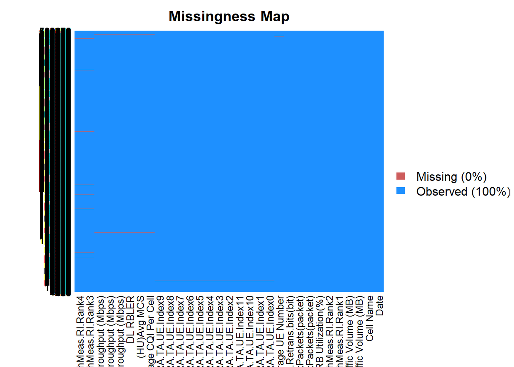

```r
missmap(LTE)
```

```r
LTE
```

```
## # A tibble: 502,246 x 31
##    Date                `Cell Name`  `(HU) Average CQI ~ `(HU) Average UE ~
##    <dttm>              <chr>                      <dbl>              <dbl>
##  1 2018-03-01 00:00:00 L21_L4404_02               11.8                2.46
##  2 2018-03-01 00:00:00 L18_LK2342_~               10.4               10.9
##  3 2018-03-01 00:00:00 L21_L1875_01               10.6                1.47
##  4 2018-03-01 00:00:00 L21_L6034_04                9.42              31.9
##  5 2018-03-01 00:00:00 L21_LU4720_~                9.36               1.09
##  6 2018-03-01 00:00:00 L21_L0084_02               11.0               37.0
##  7 2018-03-01 00:00:00 L21_L2884_01               10.4               21.5
##  8 2018-03-01 00:00:00 L21_LR2682_~               10.7               20.6
##  9 2018-03-01 00:00:00 L21_L1824_02               10.6               19.2
## 10 2018-03-01 00:00:00 L21_L6210_01               10.2               20.0
## # ... with 502,236 more rows, and 27 more variables: `(HU) Cell DL Average
## #   Throughput (Mbps)` <dbl>, `(HU) DL Traffic Volume (MB)` <dbl>, `(HU)
## #   UL Traffic Volume (MB)` <dbl>, `(HU) User DL Average Throughput
## #   (Mbps)` <dbl>, `(HU) User UL Average Throughput (Mbps)` <dbl>,
## #   `(HU)Avg MCS` <dbl>, `DL RBLER` <dbl>, L.ChMeas.RI.Rank1 <int>,
## #   L.ChMeas.RI.Rank2 <int>, L.ChMeas.RI.Rank3 <int>,
## #   L.ChMeas.RI.Rank4 <int>, `(HU) DL PRB Utilization(%)` <dbl>,
## #   L.RA.TA.UE.Index0 <int>, L.RA.TA.UE.Index1 <int>,
## #   L.RA.TA.UE.Index10 <int>, L.RA.TA.UE.Index11 <int>,
## #   L.RA.TA.UE.Index2 <int>, L.RA.TA.UE.Index3 <int>,
## #   L.RA.TA.UE.Index4 <int>, L.RA.TA.UE.Index5 <int>,
## #   L.RA.TA.UE.Index6 <int>, L.RA.TA.UE.Index7 <int>,
## #   L.RA.TA.UE.Index8 <int>, L.RA.TA.UE.Index9 <int>,
## #   `L.Traffic.DL.AM.Retrans.bits(bit)` <int>,
## #   `L.Traffic.DL.AM.Retrans.TxPackets(packet)` <int>,
## #   `L.Traffic.DL.AM.TxPackets(packet)` <int>
```

Selecting and renamming Variables

```r
#LTE <- LTE %>% select(Date, `Cell Name`,`(HU) Average CQI Per Cell`, `(HU) Average UE Number`, `(HU) User DL Average Throughput (Mbps)`, `(HU) DL Traffic Volume (MB)`, `(HU) UL Traffic Volume (MB)`, `(HU) User UL Average Throughput (Mbps)`, `(HU) DL PRB Utilization(%)`, starts_with('L.RA'))

LTE <- LTE %>% rename(CQI = `(HU) Average CQI Per Cell`,avg_ue = `(HU) Average UE Number`,avg_dl_cell_throughput = `(HU) Cell DL Average Throughput (Mbps)`,avg_dl_user_throughput = `(HU) User DL Average Throughput (Mbps)`,avg_ul_user_throughput = `(HU) User UL Average Throughput (Mbps)`,dl_traffic = `(HU) DL Traffic Volume (MB)`,ul_traffic = `(HU) UL Traffic Volume (MB)`,ul_traffic = `(HU) UL Traffic Volume (MB)`,avg_ul_user_throughput = `(HU) User UL Average Throughput (Mbps)`,prb_utilization = `(HU) DL PRB Utilization(%)`, avg_mcs = `(HU)Avg MCS`)

LTE
```

```
## # A tibble: 502,246 x 31
##    Date                `Cell Name`     CQI avg_ue avg_dl_cell_throughput
##    <dttm>              <chr>         <dbl>  <dbl>                  <dbl>
##  1 2018-03-01 00:00:00 L21_L4404_02  11.8    2.46                   8.22
##  2 2018-03-01 00:00:00 L18_LK2342_03 10.4   10.9                    8.86
##  3 2018-03-01 00:00:00 L21_L1875_01  10.6    1.47                  28.9
##  4 2018-03-01 00:00:00 L21_L6034_04   9.42  31.9                   11.5
##  5 2018-03-01 00:00:00 L21_LU4720_03  9.36   1.09                   6.54
##  6 2018-03-01 00:00:00 L21_L0084_02  11.0   37.0                   18.8
##  7 2018-03-01 00:00:00 L21_L2884_01  10.4   21.5                   10.1
##  8 2018-03-01 00:00:00 L21_LR2682_02 10.7   20.6                   10.7
##  9 2018-03-01 00:00:00 L21_L1824_02  10.6   19.2                   24.2
## 10 2018-03-01 00:00:00 L21_L6210_01  10.2   20.0                   15.5
## # ... with 502,236 more rows, and 26 more variables: dl_traffic <dbl>,
## #   ul_traffic <dbl>, avg_dl_user_throughput <dbl>,
## #   avg_ul_user_throughput <dbl>, avg_mcs <dbl>, `DL RBLER` <dbl>,
## #   L.ChMeas.RI.Rank1 <int>, L.ChMeas.RI.Rank2 <int>,
## #   L.ChMeas.RI.Rank3 <int>, L.ChMeas.RI.Rank4 <int>,
## #   prb_utilization <dbl>, L.RA.TA.UE.Index0 <int>,
## #   L.RA.TA.UE.Index1 <int>, L.RA.TA.UE.Index10 <int>,
## #   L.RA.TA.UE.Index11 <int>, L.RA.TA.UE.Index2 <int>,
## #   L.RA.TA.UE.Index3 <int>, L.RA.TA.UE.Index4 <int>,
## #   L.RA.TA.UE.Index5 <int>, L.RA.TA.UE.Index6 <int>,
## #   L.RA.TA.UE.Index7 <int>, L.RA.TA.UE.Index8 <int>,
## #   L.RA.TA.UE.Index9 <int>, `L.Traffic.DL.AM.Retrans.bits(bit)` <int>,
## #   `L.Traffic.DL.AM.Retrans.TxPackets(packet)` <int>,
## #   `L.Traffic.DL.AM.TxPackets(packet)` <int>
```

Checking the other variables where CQI is null

```r
LTE %>% filter(is.na(CQI))  %>% summary()
```

```
##       Date                      Cell Name              CQI
##  Min.   :2018-03-01 14:00:00   Length:967         Min.   : NA
##  1st Qu.:2018-03-25 15:00:00   Class :character   1st Qu.: NA
##  Median :2018-04-14 16:00:00   Mode  :character   Median : NA
##  Mean   :2018-04-17 07:03:17                      Mean   :NaN
##  3rd Qu.:2018-05-10 16:30:00                      3rd Qu.: NA
##  Max.   :2018-05-30 22:00:00                      Max.   : NA
##                                                   NA's   :967
##      avg_ue        avg_dl_cell_throughput   dl_traffic   ul_traffic
##  Min.   :0.00000   Min.   : NA            Min.   :0    Min.   :0
##  1st Qu.:0.00000   1st Qu.: NA            1st Qu.:0    1st Qu.:0
##  Median :0.00000   Median : NA            Median :0    Median :0
##  Mean   :0.02445   Mean   :NaN            Mean   :0    Mean   :0
##  3rd Qu.:0.00000   3rd Qu.: NA            3rd Qu.:0    3rd Qu.:0
##  Max.   :5.78800   Max.   : NA            Max.   :0    Max.   :0
##                    NA's   :967
##  avg_dl_user_throughput avg_ul_user_throughput    avg_mcs
##  Min.   : NA            Min.   : NA            Min.   : 0.00
##  1st Qu.: NA            1st Qu.: NA            1st Qu.: 5.85
##  Median : NA            Median : NA            Median :11.70
##  Mean   :NaN            Mean   :NaN            Mean   :11.70
##  3rd Qu.: NA            3rd Qu.: NA            3rd Qu.:17.55
##  Max.   : NA            Max.   : NA            Max.   :23.40
##  NA's   :967            NA's   :967            NA's   :965
##     DL RBLER   L.ChMeas.RI.Rank1 L.ChMeas.RI.Rank2 L.ChMeas.RI.Rank3
##  Min.   :0     Min.   :0         Min.   :0         Min.   :0
##  1st Qu.:0     1st Qu.:0         1st Qu.:0         1st Qu.:0
##  Median :0     Median :0         Median :0         Median :0
##  Mean   :0     Mean   :0         Mean   :0         Mean   :0
##  3rd Qu.:0     3rd Qu.:0         3rd Qu.:0         3rd Qu.:0
##  Max.   :0     Max.   :0         Max.   :0         Max.   :0
##  NA's   :965                                       NA's   :184
##  L.ChMeas.RI.Rank4 prb_utilization L.RA.TA.UE.Index0 L.RA.TA.UE.Index1
##  Min.   :0         Min.   :0.140   Min.   :0         Min.   :0.00000
##  1st Qu.:0         1st Qu.:1.892   1st Qu.:0         1st Qu.:0.00000
##  Median :0         Median :3.422   Median :0         Median :0.00000
##  Mean   :0         Mean   :3.107   Mean   :0         Mean   :0.00857
##  3rd Qu.:0         3rd Qu.:3.954   3rd Qu.:0         3rd Qu.:0.00000
##  Max.   :0         Max.   :8.235   Max.   :0         Max.   :6.00000
##  NA's   :184                       NA's   :33        NA's   :33
```

[output cut: 25 more lines]

```
##  Min.   :0
##  1st Qu.:0
##  Median :0
##  Mean   :0
##  3rd Qu.:0
##  Max.   :0
##
##  L.Traffic.DL.AM.TxPackets(packet)
##  Min.   :0
##  1st Qu.:0
##  Median :0
##  Mean   :0
##  3rd Qu.:0
##  Max.   :0
##
```

How many are they ?

```r
LTE %>% filter(is.na(CQI)) %>% summarise(n())
```

```
## # A tibble: 1 x 1
##   `n()`
##   <int>
## 1   967
```

```r
LTE %>% filter(!is.na(CQI))  %>% summary()
```

```
##       Date                      Cell Name              CQI
##  Min.   :2018-03-01 00:00:00   Length:501279      Min.   : 0.3082
##  1st Qu.:2018-03-26 23:00:00   Class :character   1st Qu.: 9.6962
##  Median :2018-04-18 21:00:00   Mode  :character   Median :10.4493
##  Mean   :2018-04-17 21:32:42                      Mean   :10.5005
##  3rd Qu.:2018-05-10 18:00:00                      3rd Qu.:11.2460
##  Max.   :2018-05-30 23:00:00                      Max.   :15.0000
##
##      avg_ue        avg_dl_cell_throughput   dl_traffic
##  Min.   :  0.000   Min.   : 0.000         Min.   :    0.0
##  1st Qu.:  3.369   1st Qu.: 9.161         1st Qu.:  373.7
##  Median :  8.895   Median :12.462         Median :  827.9
##  Mean   : 13.419   Mean   :13.496         Mean   : 1125.4
##  3rd Qu.: 18.034   3rd Qu.:16.474         3rd Qu.: 1538.1
##  Max.   :379.472   Max.   :91.276         Max.   :17253.9
##  NA's   :549       NA's   :494
##    ul_traffic       avg_dl_user_throughput avg_ul_user_throughput
##  Min.   :    0.00   Min.   :  0.000        Min.   : 0.0000
##  1st Qu.:   22.58   1st Qu.:  7.559        1st Qu.: 0.9957
##  Median :   60.59   Median : 11.321        Median : 1.4447
##  Mean   :  112.53   Mean   : 13.140        Mean   : 1.7639
##  3rd Qu.:  134.88   3rd Qu.: 16.598        3rd Qu.: 2.0636
##  Max.   :10244.17   Max.   :101.503        Max.   :32.4749
##                     NA's   :840            NA's   :553
##     avg_mcs         DL RBLER       L.ChMeas.RI.Rank1  L.ChMeas.RI.Rank2
##  Min.   : 0.00   Min.   : 0.0000   Min.   :       0   Min.   :       0
##  1st Qu.:15.84   1st Qu.: 0.0899   1st Qu.:  135904   1st Qu.:  151782
##  Median :17.56   Median : 0.1721   Median :  453992   Median :  468579
##  Mean   :17.65   Mean   : 0.2718   Mean   :  727201   Mean   :  673617
##  3rd Qu.:19.36   3rd Qu.: 0.2991   3rd Qu.:  979348   3rd Qu.:  940682
##  Max.   :28.74   Max.   :76.9231   Max.   :10358628   Max.   :10633966
##  NA's   :8       NA's   :8
##  L.ChMeas.RI.Rank3  L.ChMeas.RI.Rank4  prb_utilization  L.RA.TA.UE.Index0
##  Min.   :     0.0   Min.   :     0.0   Min.   : 1.515   Min.   :    0.00
##  1st Qu.:     0.0   1st Qu.:     0.0   1st Qu.: 9.279   1st Qu.:    0.00
##  Median :     0.0   Median :     0.0   Median :17.402   Median :    9.00
##  Mean   :    29.8   Mean   :     7.4   Mean   :22.324   Mean   :   69.43
##  3rd Qu.:     0.0   3rd Qu.:     0.0   3rd Qu.:30.251   3rd Qu.:   64.00
##  Max.   :460259.0   Max.   :151681.0   Max.   :99.771   Max.   :19219.00
##  NA's   :2244       NA's   :2244                        NA's   :695
```

[output cut: 33 more lines]

```
##  Min.   :      0
##  1st Qu.:   4929
##  Median :  12477
##  Mean   :  20248
##  3rd Qu.:  24003
##  Max.   :4905597
##
##  L.Traffic.DL.AM.TxPackets(packet)
##  Min.   :       0
##  1st Qu.:  403507
##  Median :  940487
##  Mean   : 1403205
##  3rd Qu.: 1847080
##  Max.   :25973348
##
```

Clearly the prb has increased once the CQI is not null (the cell is active) and other variables carry a representable number Checking if ever variables carry 0 value similtinously (Which may indicates also a non functioning cell)

```r
LTE %>% filter(CQI ==0,avg_ue == 0, avg_dl_user_throughput == 0 ) %>% summarise(n())
```

```
## # A tibble: 1 x 1
##   `n()`
##   <int>
## 1     0
```

Now I can remove nulls confidently that they have no value and no other condition may indicate a non functioning cell that can corrupt our model

```r
LTE <- LTE %>% filter(!is.na(CQI))
```

Lets see how many rows remaining

```r
length(LTE$CQI)
```

```
## [1] 501279
```

```r
summary(LTE)
```

```
##       Date                      Cell Name              CQI
##  Min.   :2018-03-01 00:00:00   Length:501279      Min.   : 0.3082
##  1st Qu.:2018-03-26 23:00:00   Class :character   1st Qu.: 9.6962
##  Median :2018-04-18 21:00:00   Mode  :character   Median :10.4493
##  Mean   :2018-04-17 21:32:42                      Mean   :10.5005
##  3rd Qu.:2018-05-10 18:00:00                      3rd Qu.:11.2460
##  Max.   :2018-05-30 23:00:00                      Max.   :15.0000
##
##      avg_ue        avg_dl_cell_throughput   dl_traffic
##  Min.   :  0.000   Min.   : 0.000         Min.   :    0.0
##  1st Qu.:  3.369   1st Qu.: 9.161         1st Qu.:  373.7
##  Median :  8.895   Median :12.462         Median :  827.9
##  Mean   : 13.419   Mean   :13.496         Mean   : 1125.4
##  3rd Qu.: 18.034   3rd Qu.:16.474         3rd Qu.: 1538.1
##  Max.   :379.472   Max.   :91.276         Max.   :17253.9
##  NA's   :549       NA's   :494
##    ul_traffic       avg_dl_user_throughput avg_ul_user_throughput
##  Min.   :    0.00   Min.   :  0.000        Min.   : 0.0000
##  1st Qu.:   22.58   1st Qu.:  7.559        1st Qu.: 0.9957
##  Median :   60.59   Median : 11.321        Median : 1.4447
##  Mean   :  112.53   Mean   : 13.140        Mean   : 1.7639
##  3rd Qu.:  134.88   3rd Qu.: 16.598        3rd Qu.: 2.0636
##  Max.   :10244.17   Max.   :101.503        Max.   :32.4749
##                     NA's   :840            NA's   :553
##     avg_mcs         DL RBLER       L.ChMeas.RI.Rank1  L.ChMeas.RI.Rank2
##  Min.   : 0.00   Min.   : 0.0000   Min.   :       0   Min.   :       0
##  1st Qu.:15.84   1st Qu.: 0.0899   1st Qu.:  135904   1st Qu.:  151782
##  Median :17.56   Median : 0.1721   Median :  453992   Median :  468579
##  Mean   :17.65   Mean   : 0.2718   Mean   :  727201   Mean   :  673617
##  3rd Qu.:19.36   3rd Qu.: 0.2991   3rd Qu.:  979348   3rd Qu.:  940682
##  Max.   :28.74   Max.   :76.9231   Max.   :10358628   Max.   :10633966
##  NA's   :8       NA's   :8
##  L.ChMeas.RI.Rank3  L.ChMeas.RI.Rank4  prb_utilization  L.RA.TA.UE.Index0
##  Min.   :     0.0   Min.   :     0.0   Min.   : 1.515   Min.   :    0.00
##  1st Qu.:     0.0   1st Qu.:     0.0   1st Qu.: 9.279   1st Qu.:    0.00
##  Median :     0.0   Median :     0.0   Median :17.402   Median :    9.00
##  Mean   :    29.8   Mean   :     7.4   Mean   :22.324   Mean   :   69.43
##  3rd Qu.:     0.0   3rd Qu.:     0.0   3rd Qu.:30.251   3rd Qu.:   64.00
##  Max.   :460259.0   Max.   :151681.0   Max.   :99.771   Max.   :19219.00
##  NA's   :2244       NA's   :2244                        NA's   :695
```

[output cut: 33 more lines]

```
##  Min.   :      0
##  1st Qu.:   4929
##  Median :  12477
##  Mean   :  20248
##  3rd Qu.:  24003
##  Max.   :4905597
##
##  L.Traffic.DL.AM.TxPackets(packet)
##  Min.   :       0
##  1st Qu.:  403507
##  Median :  940487
##  Mean   : 1403205
##  3rd Qu.: 1847080
##  Max.   :25973348
##
```

Lets look at our target variable

from the summary we can see that it is a little right skewed means that there is users in some cells gets a extremly high avg throughput OK lets look

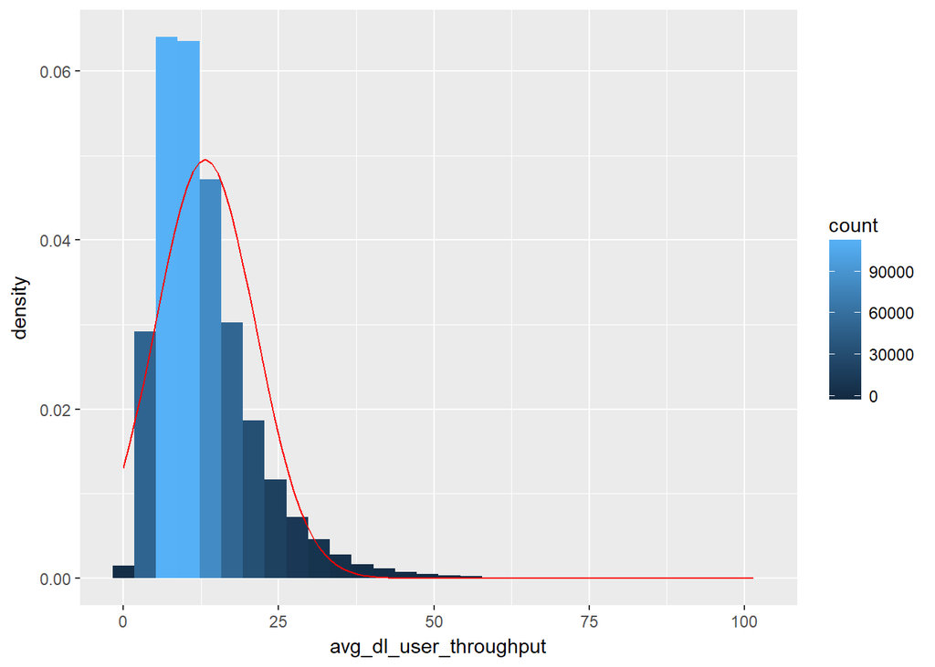

```r
LTE %>% ggplot(aes(x = avg_dl_user_throughput)) + geom_histogram(aes(y = ..density.., fill = ..count..)) + stat_function(fun = dnorm,color = 'red' ,args = list(mean = mean(LTE$avg_dl_user_throughput, na.rm = T),sd= sd(LTE$avg_dl_user_throughput, na.rm = T)))
```

Using log the variable

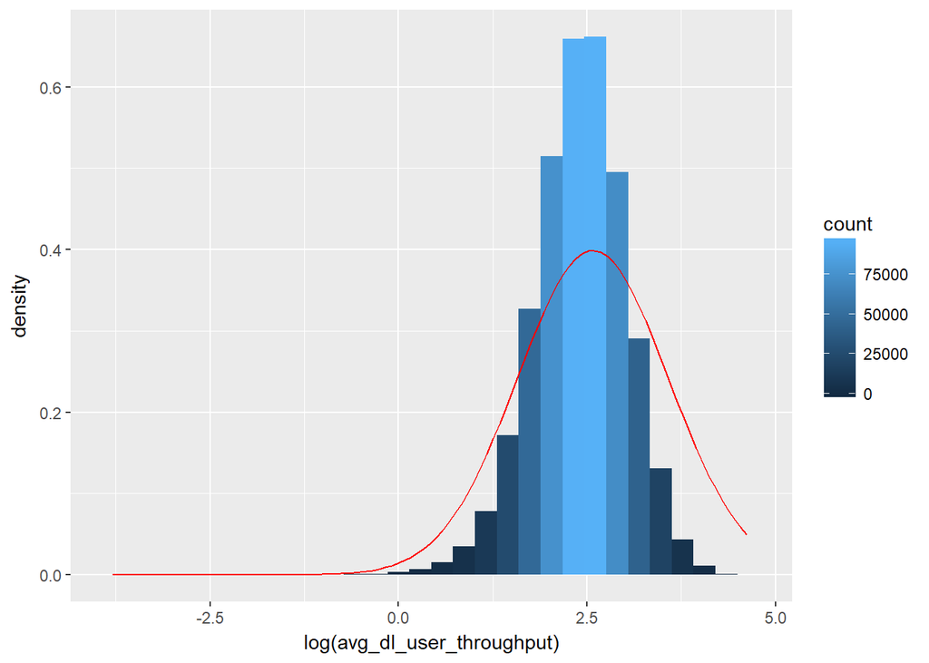

```r
LTE %>% ggplot(aes(x = log(avg_dl_user_throughput))) + geom_histogram(aes(y = ..density.., fill = ..count..)) + stat_function(fun = dnorm,color = 'red' ,args = list(mean = log(mean(LTE$avg_dl_user_throughput, na.rm = T))),sd= sd(log(LTE$avg_dl_user_throughput), na.rm = T))
```

Note to self:- (I have a question regarding the Avg ue, What is the granular time windiw that is avereged for each hour ?) unpivot and see what is the most used distance from indexes use standard deviasio as a method of detcting abnormalty (after applying significant groupping)

# Now Lets see what are those extreme cells ? are the distribution of avg user throughput related to certain mode of transmission and reception or even the band ?

importing and joining the LTE join the data sets to see

```r
LTE_cells <- read_excel("E:/Academic/ITI/PROJECT/project network/lte/Data/DataSet/LTE cells.xlsx")
LTE_cells <- LTE_cells %>% rename(`Cell Name` = `*Cell Name`)

LTE_det <- left_join(LTE, LTE_cells)
LTE_det <-  LTE_det %>% rename(band = `*Downlink bandwidth`, trans_recep_mode = `*Cell transmission and reception mode`)
```

Making sure of complete join

```r
LTE_det %>%  filter(is.na(band) & is.na(trans_recep_mode))%>% summarise(n_distinct(`Cell Name`), n())
```

```
## # A tibble: 1 x 2
##   `n_distinct(\`Cell Name\`)` `n()`
##                         <int> <int>
## 1                         226  4225
```

There is 226 cell without a refrence in LTE_cells reprsenting 4225 instance

# Now seeing if the Cell band affects the throughput

```r
LTE_det %>% group_by(band) %>% summarise(mean(avg_dl_user_throughput, na.rm = T), n_distinct(`Cell Name`), sd(avg_dl_user_throughput, na.rm = T))
```

```
## # A tibble: 5 x 4
##   band        `mean(avg_dl_user_th~ `n_distinct(\`Cel~ `sd(avg_dl_user_th~
##   <chr>                       <dbl>              <int>               <dbl>
## 1 CELL_BW_N15                  4.62                 19                3.56
## 2 CELL_BW_N25                  8.79               2968                4.49
## 3 CELL_BW_N50                 15.9                3543                8.55
## 4 CELL_BW_N75                 16.0                   3                5.08
## 5 <NA>                        16.7                 226               10.5
```

Notice that the N50 band has the highest standard deviasion in all bands

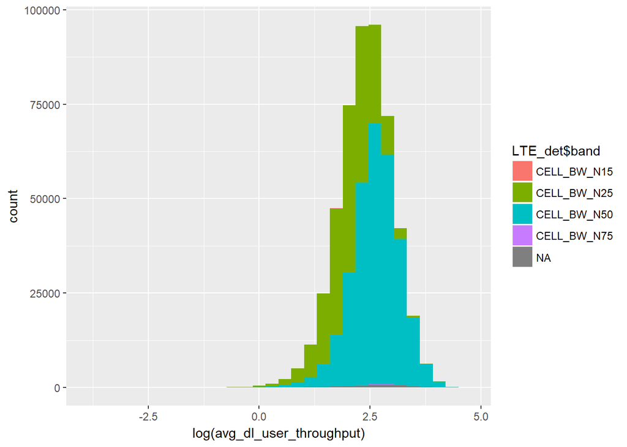

```r
LTE_det %>% ggplot(aes(x = log(avg_dl_user_throughput))) + geom_histogram(aes(fill = LTE_det$band))
```

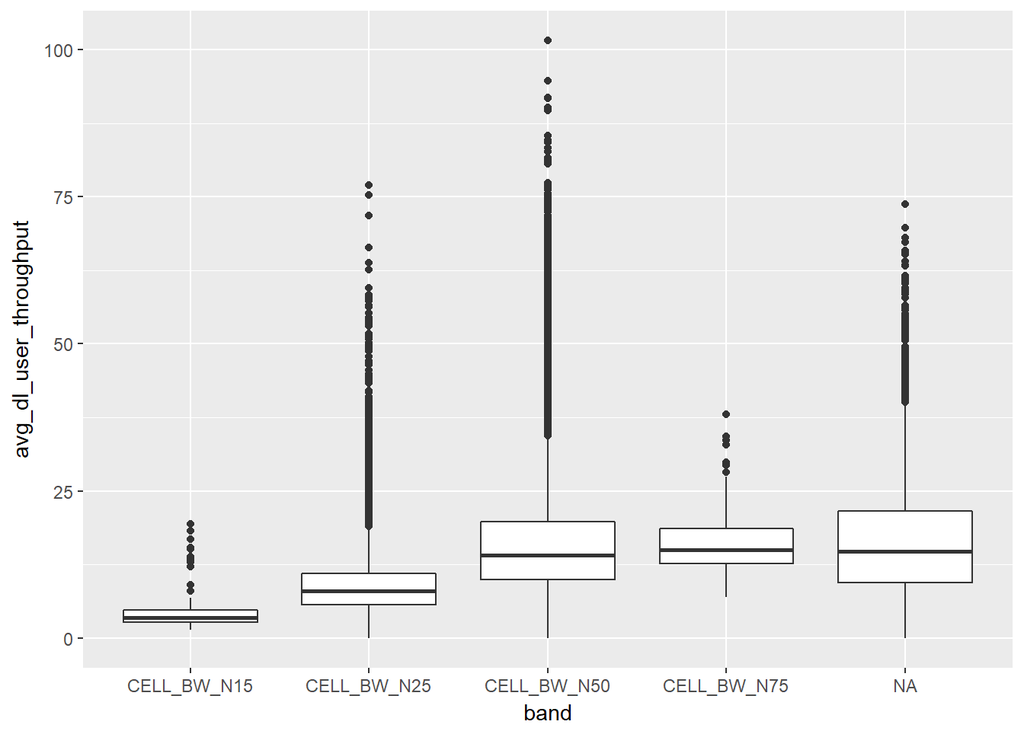

```r
LTE_det %>% ggplot(aes(x= band, y = avg_dl_user_throughput)) + geom_boxplot()
```

making annova to see diffrence

```r
LTE_fin <- LTE_det %>% filter(is.finite(log(avg_dl_user_throughput)))
aov_band <- aov(data = LTE_fin, log(LTE_fin$avg_dl_user_throughput) ~ LTE_fin$band)

summary(aov_band)
```

```
##                  Df Sum Sq Mean Sq F value Pr(>F)
## LTE_fin$band      3  39802   13267   45898 <2e-16 ***
## Residuals    496295 143459       0
## ---
## Signif. codes:  0 '***' 0.001 '**' 0.01 '*' 0.05 '.' 0.1 ' ' 1
## 4127 observations deleted due to missingness
```

```r
TukeyHSD(aov_band)
```

```
##   Tukey multiple comparisons of means
##     95% family-wise confidence level
##
## Fit: aov(formula = log(LTE_fin$avg_dl_user_throughput) ~ LTE_fin$band, data = LTE_fin)
##
## $`LTE_fin$band`
##                              diff        lwr       upr     p adj
## CELL_BW_N25-CELL_BW_N15 0.6945339 0.56892887 0.8201390 0.0000000
## CELL_BW_N50-CELL_BW_N15 1.2743792 1.14878839 1.3999700 0.0000000
## CELL_BW_N75-CELL_BW_N15 1.3776501 1.22680267 1.5284975 0.0000000
## CELL_BW_N50-CELL_BW_N25 0.5798453 0.57582259 0.5838679 0.0000000
## CELL_BW_N75-CELL_BW_N25 0.6831161 0.59946165 0.7667706 0.0000000
## CELL_BW_N75-CELL_BW_N50 0.1032709 0.01963782 0.1869040 0.0082369
```

Checjing homogenicity of variance

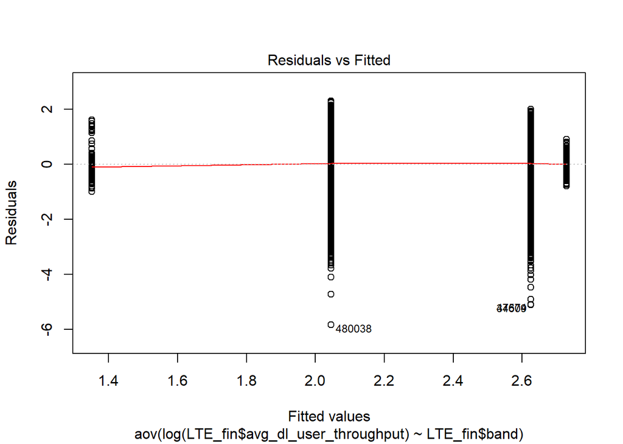

```r
plot(aov_band,1)
```

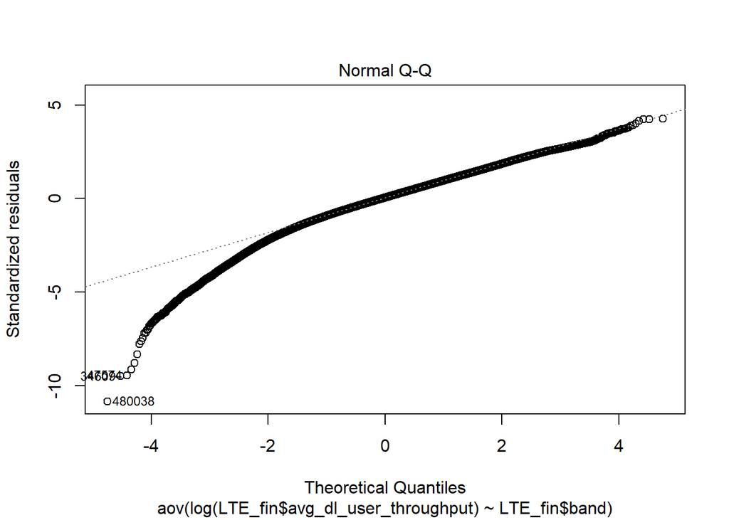

```r
plot(aov_band,2)
```

Does the mode affets with the band

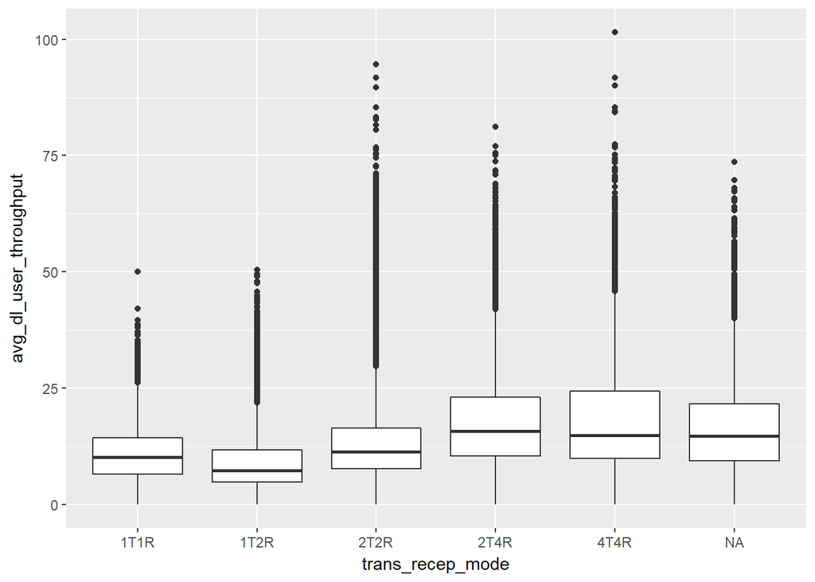

```r
LTE_det %>% ggplot(aes(x= trans_recep_mode, y = avg_dl_user_throughput)) + geom_boxplot()
```

Now seeing if the trans mode make differ

```r
aov_trans <- aov(data = LTE_fin, log(LTE_fin$avg_dl_user_throughput) ~ LTE_fin$trans_recep_mode)

summary(aov_trans)
```

```
##                              Df Sum Sq Mean Sq F value Pr(>F)
## LTE_fin$trans_recep_mode      4   5863  1465.8    4101 <2e-16 ***
## Residuals                496294 177397     0.4
## ---
## Signif. codes:  0 '***' 0.001 '**' 0.01 '*' 0.05 '.' 0.1 ' ' 1
## 4127 observations deleted due to missingness
```

```r
TukeyHSD(aov_trans)
```

```
##   Tukey multiple comparisons of means
##     95% family-wise confidence level
##
## Fit: aov(formula = log(LTE_fin$avg_dl_user_throughput) ~ LTE_fin$trans_recep_mode, data = LTE_fin)
##
## $`LTE_fin$trans_recep_mode`
##                  diff        lwr         upr     p adj
## 1T2R-1T1R -0.20427580 -0.2269515 -0.18160009 0.0000000
## 2T2R-1T1R  0.17120774  0.1509511  0.19146443 0.0000000
## 2T4R-1T1R  0.48885386  0.4644908  0.51321689 0.0000000
## 4T4R-1T1R  0.48413242  0.4575233  0.51074150 0.0000000
## 2T2R-1T2R  0.37548354  0.3647192  0.38624783 0.0000000
## 2T4R-1T2R  0.69312966  0.6758353  0.71042400 0.0000000
## 4T4R-1T2R  0.68840822  0.6680716  0.70874488 0.0000000
## 2T4R-2T2R  0.31764612  0.3036733  0.33161894 0.0000000
## 4T4R-2T2R  0.31292468  0.2953257  0.33052369 0.0000000
## 4T4R-2T4R -0.00472144 -0.0269239  0.01748102 0.9780336
```

We can see that 4T4R doesnot differ from 2T4R and 1T2R is lower than 1T1R

Lets see both the band and the trans mode

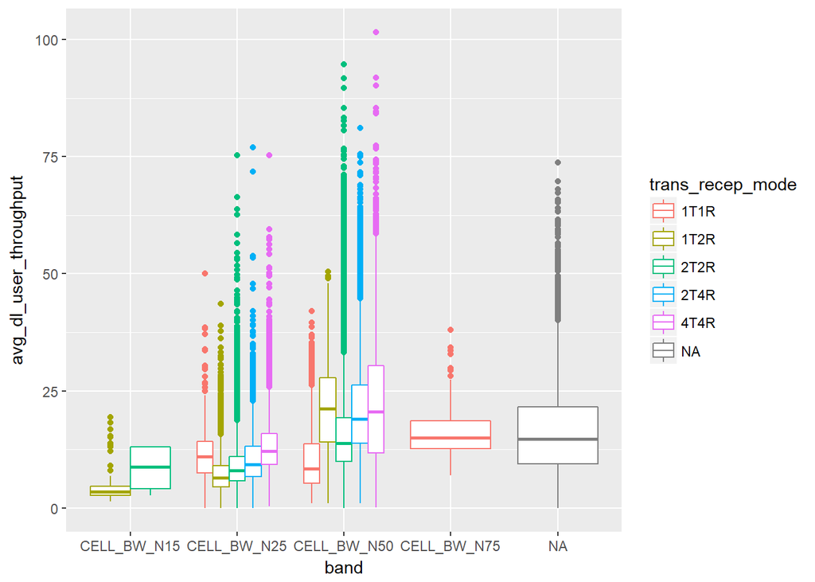

```r
LTE_det %>% ggplot(aes(y= avg_dl_user_throughput, x = band)) + geom_boxplot(aes(color = trans_recep_mode))
```

```r
LTE_det %>% group_by(band, trans_recep_mode) %>%  summarise(mean(avg_dl_user_throughput, na.rm = T), n_distinct(`Cell Name`), sd(avg_dl_user_throughput, na.rm = T))
```

```
## # A tibble: 14 x 5
## # Groups:   band [?]
##    band     trans_recep_mode `mean(avg_dl_user_throug~ `n_distinct(\`Cell~
##    <chr>    <chr>                                <dbl>               <int>
##  1 CELL_BW~ 1T2R                                  4.49                  11
##  2 CELL_BW~ 2T2R                                  8.35                   8
##  3 CELL_BW~ 1T1R                                 10.9                   39
##  4 CELL_BW~ 1T2R                                  7.13                 336
##  5 CELL_BW~ 2T2R                                  8.79                2476
##  6 CELL_BW~ 2T4R                                 10.5                   69
##  7 CELL_BW~ 4T4R                                 13.4                   48
##  8 CELL_BW~ 1T1R                                 10.9                   34
##  9 CELL_BW~ 1T2R                                 20.9                   51
## 10 CELL_BW~ 2T2R                                 15.5                 3277
## 11 CELL_BW~ 2T4R                                 21.2                  126
## 12 CELL_BW~ 4T4R                                 22.4                   55
## 13 CELL_BW~ 1T1R                                 16.0                    3
## 14 <NA>     <NA>                                 16.7                  226
## # ... with 1 more variable: `sd(avg_dl_user_throughput, na.rm = T)` <dbl>
```

Joining the region table to see if the region or subregion affects